# High School Seniors t Test

### Do Men Play Video Games More Than Women?

Have you made the assumption that men play video games more than women? Let’s see what the data says…

Hypothesis: Null: There is not a significant difference between the average number of hours men and women play video games.

```r
library(tidyverse)
library(DT)
library(pander)
library(readr)
library(car)

HSS <- read_csv("../../Data/HighSchoolSeniors.csv")
#Remember: select "Session, Set Working Directory, To Source File Location", and then play this R-chunk into your console to read the HSS data into R.
```

#### Histogram

As we look at the data directly, we can see how heavily the data skews to the right; most women don’t play video games, or play very little video games. Just looking at the histogram, we can already start to see the difference in video game usage between males and females.

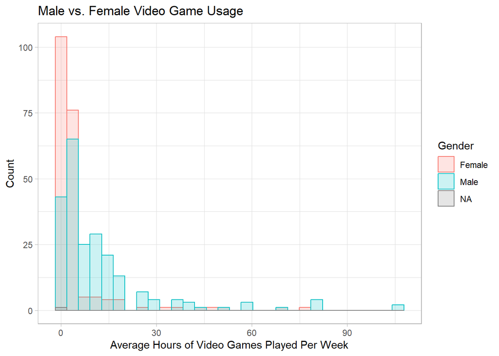

```r
ggplot(HSS) +
  geom_histogram(
    aes(x=Video_Games_Hours,
        fill= Gender,
        color= Gender),
    alpha=0.2,
    position='identity'
    ) +
  theme_light() +
  labs(title="Male vs. Female Video Game Usage",
       x="Average Hours of Video Games Played Per Week",
       y="Count")
```

#### Q-Q Plots

Let’s gauge the normalization of our data. Here we can clearly see a severe skew:

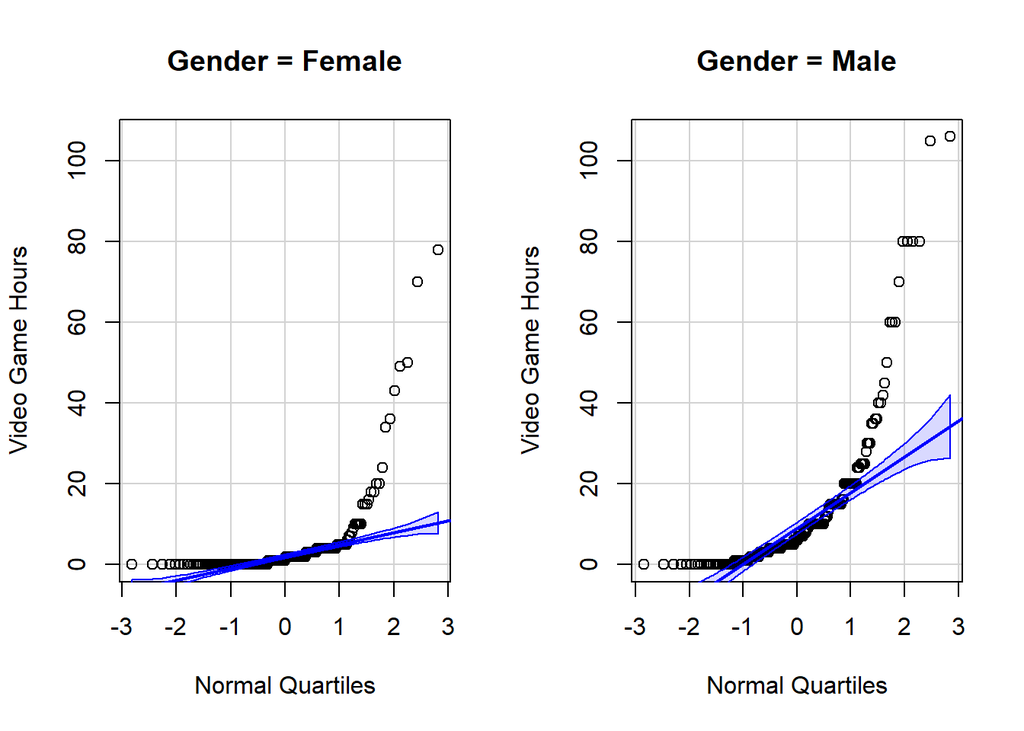

```r
qqPlot(Video_Games_Hours ~ Gender, data=HSS,
       xlab= "Normal Quartiles",
       ylab= "Video Game Hours",
       id=list(method="n"))
```

#### Data Normalization

Regardless of this skew, our large sample of data will make up for that allowing us to still get accurate results with an independent t-test. Sample Size:

```r
pander(table(HSS$Gender))
```

| Female | Male |
| --- | --- |
| 232 | 262 |

#### T-Test & Conclusion

```r
t_test <- t.test(Video_Games_Hours ~ Gender, data=HSS, alternative="less")
pander(t_test)
```

Welch Two Sample t-test: `Video_Games_Hours` by `Gender` (continued below)

| Test statistic | df | P value | Alternative hypothesis |
| --- | --- | --- | --- |
| -5.841 | 368.3 | 5.697e-09 * * * | less |

| mean in group Female | mean in group Male |
| --- | --- |
| 4.238 | 12.15 |

P < 0.05, therefore there is sufficient evidence to reject the null hypothesis. On average, men play video games more than women every week. The sample data showed men playing, on average, about 8 hours more than women